# World Cup 2022

The world cup 2022 will be hosted by Qatar in 2022. We wanted to try and predict which country has the biggest probability of winning the tournament by using supervised learning.

## 1. Data

The data that we will be using is already cleaned and does not require a lot of pre-processing.

The data set provides a complete overview of all international football matches played since the 90s. On top of that, the strength of each team is provided by incorporating the FIFA rankings as well as player strengths based on the EA Sport FIFA video game. It is available on [kaggle](https://www.kaggle.com/datasets/brenda89/fifa-world-cup-2022)

## Variables

- `home_team_mean_midfield_score` : Average FIFA game score of the 4 highest ranked midfield players of the home team
- `away_team_mean_midfield_score` : Average FIFA game score of the 4 highest ranked midfield players of the away team
- `home_team_mean_offense_score` : Average FIFA game score of the 3 highest ranked attacking players of the home team, including wing players
- `away_team_mean_offense_score` : Average FIFA game score of the 3 highest ranked attacking players of the away team, including wing players

### Import all the libraries

with rpy2 we can use R for EDA

```python
!pip install rpy2
```

```python
import numpy as np
import pandas as pd
import seaborn as sns
import matplotlib.pyplot as plt

from sklearn import linear_model
from sklearn import ensemble
from sklearn.model_selection import train_test_split
from sklearn.metrics import confusion_matrix, roc_curve, roc_auc_score
from sklearn.pipeline import Pipeline
from sklearn.preprocessing import PolynomialFeatures
```

```python
%load_ext rpy2.ipython


df = pd.read_csv('data/input_data.csv')
```

```python
%%R -i df -w 5 -h 5 --units in -r 200

#install.packages("ggplot2", repos='http://cran.us.r-project.org')
#install.packages("dplyr", repos='http://cran.us.r-project.org')
#install.packages("skimr", repos='http://cran.us.r-project.org')
#install.packages("plotly", repos='http://cran.us.r-project.org')
#install.packages("scales", repos='http://cran.us.r-project.org')
#install.packages("corrplot", repos='http://cran.us.r-project.org')
#install.packages("tidyverse", repos='http://cran.us.r-project.org')


#library(ggplot2)
#library(dplyr)
#library(skimr)
#library(plotly)
#library(scales)
#library(corrplot)
#library(tidyverse)
```

## Descriptive statistics

We have data for 23921 international matches, ranging from 1993 to 2022. We can also see that most of the data is complete except for the old fifa scores. We can also determine whether a match has been played at a neutral pitch or not.

```python
%%R

df$date <- as.Date(df$date)
skim_without_charts(df)
```

```
── Data Summary ────────────────────────
                           Values
Name                       df
Number of rows             23921
Number of columns          25
_______________________
Column type frequency:
  character                9
  Date                     1
  logical                  1
  numeric                  14
________________________
Group variables            None

── Variable type: character ────────────────────────────────────────────────────
  skim_variable       n_missing complete_rate min max empty n_unique whitespace
1 home_team                   0             1   3  30     0      211          0
2 away_team                   0             1   3  30     0      211          0
3 home_team_continent         0             1   4  13     0        6          0
4 away_team_continent         0             1   4  13     0        6          0
5 tournament                  0             1   7  42     0       82          0
6 city                        0             1   2  28     0     1576          0
7 country                     0             1   3  30     0      217          0
8 shoot_out                   0             1   2   3     0        2          0
9 home_team_result            0             1   3   4     0        3          0

── Variable type: Date ─────────────────────────────────────────────────────────
  skim_variable n_missing complete_rate min        max        median
1 date                  0             1 1993-08-08 2022-06-14 2008-10-26
  n_unique
1     5550

── Variable type: logical ──────────────────────────────────────────────────────
  skim_variable    n_missing complete_rate  mean count
1 neutral_location         0             1 0.250 FAL: 17947, TRU: 5974

── Variable type: numeric ──────────────────────────────────────────────────────
   skim_variable                 n_missing complete_rate   mean     sd   p0  p25
 1 home_team_fifa_rank                   0         1      77.9   52.4   1   33
 2 away_team_fifa_rank                   0         1      80.8   53.2   1   36
```

[output cut: 12 more lines]

```
    p50   p75   p100
 1 71   115    211
 2 73   119    211
 3  0   547   2164
 4  0   523   2164
 5  1     2     31
 6  1     2     21
 7 75    81     97
 8 74    80     97
 9 75.2  78.8   91.8
10 75.7  80     93
11 76.2  79.5   93.2
12 74.5  78.2   91.8
13 75.3  79.7   93
14 75.5  79     93.2
```

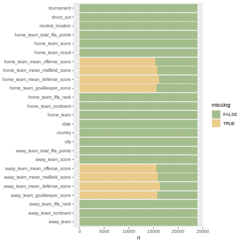

```python
%%R

df %>%
  summarise_all(list(~is.na(.)))%>%
  pivot_longer(everything(),
               names_to = "variables", values_to="missing") %>%
  count(variables, missing) %>%
  ggplot(aes(y=variables,x=n,fill=missing))+
  geom_col()+
  scale_fill_manual(values=c("#A3BE8C","#EBCB8B"))+
  theme(axis.title.y=element_blank())
```

### Top 10 teams in 2022

These are the 10 best teams of 2022 using the fifa ranking metric.

```python
%%R

home <-
  input_data %>%
  select(date, home_team, home_team_fifa_rank) %>%
  rename(team = home_team, ranking = home_team_fifa_rank)

away <-
  input_data %>%
  select(date, away_team, away_team_fifa_rank) %>%
  rename(team = away_team, ranking = away_team_fifa_rank)

fifa_ranking <- rbind(home, away)

latest_fifa_ranking <-
  fifa_ranking %>%
  arrange(team, desc(date)) %>%
  group_by(team) %>%
  mutate(row_number = row_number(team)) %>%
  filter(row_number == 1) %>%
  select(-row_number, -date) %>%
  arrange(ranking)

head(latest_fifa_ranking, 10)
```

```
# A tibble: 10 × 2
# Groups:   team [10]
   team        ranking
   <chr>         <dbl>
 1 Brazil            1
 2 Belgium           2
 3 France            3
 4 Argentina         4
 5 England           5
 6 Italy             6
 7 Spain             7
 8 Portugal          8
 9 Mexico            9
10 Netherlands      10
```

### How did the top 5 teams in 2022 perform over time

The best teams in 2022 weren't always at the top of the ranking board. Some teams, such as Belgium only recently became a top team.

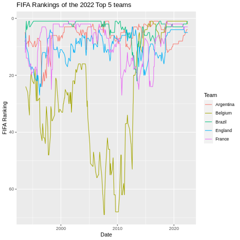

```python
%%R

top5_list <- head(latest_fifa_ranking, 5)$team

top5_ranking <-
  fifa_ranking  %>%
  filter(team %in% top5_list)

ggplot(data = top5_ranking,
         mapping = aes(
           x = date,
           y = ranking,
           group = team,
           color = team
         )) +
  geom_line() +
  scale_y_reverse() +
  labs(
    x = "Date",
    y = "FIFA Ranking",
    color = "Team",
    title = "FIFA Rankings of the 2022 Top 5 teams"
  )
```

### Top 10 GK in 2022

These are the 10 countries with the best goalkeepers using the fifa score metric.

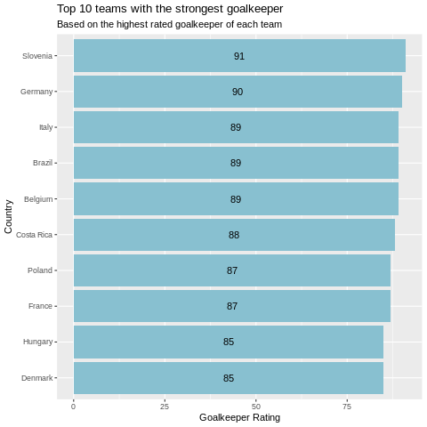

```python
%%R

gk_home <-
  df %>%
  select(date, home_team, home_team_goalkeeper_score) %>%
  rename(team = home_team, goalkeeper_rating = home_team_goalkeeper_score)

gk_away <-
  df %>%
  select(date, away_team, away_team_goalkeeper_score) %>%
  rename(team = away_team, goalkeeper_rating = away_team_goalkeeper_score)

gk_rating <- drop_na(rbind(gk_home, gk_away))

latest_gk_rating <-
  gk_rating %>%
  arrange(team, desc(date)) %>%
  group_by(team) %>%
  mutate(row_number = row_number(team)) %>%
  filter(row_number == 1) %>%
  select(-row_number, -date) %>%
  arrange(-goalkeeper_rating)

ggplot(data = head(latest_gk_rating, 10), mapping = aes(x=goalkeeper_rating, y=reorder(team, goalkeeper_rating), label=goalkeeper_rating)) +
  geom_col(fill="#88C0D0") +
  geom_text(position = position_stack(vjust = 0.5)) +
  labs(title = "Top 10 teams with the strongest goalkeeper",
       subtitle = "Based on the highest rated goalkeeper of each team",
       x="Goalkeeper Rating",
       y="Country")
```

### Top 10 defenses in 2022

These are the 10 countries with the best defense (gk + defenders) using the fifa score metric.

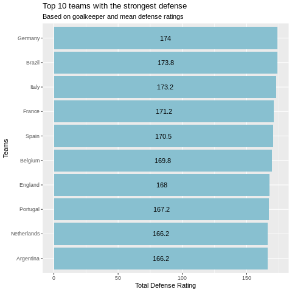

```python
%%R

def_home <-
  df %>%
  select(date, home_team, home_team_goalkeeper_score, home_team_mean_defense_score) %>%
  rename(team = home_team, goalkeeper_rating = home_team_goalkeeper_score, mean_defense_rating = home_team_mean_defense_score)

def_away <-
  df %>%
  select(date, away_team, away_team_goalkeeper_score, away_team_mean_defense_score) %>%
  rename(team = away_team, goalkeeper_rating = away_team_goalkeeper_score, mean_defense_rating = away_team_mean_defense_score)

def_rating <- drop_na(rbind(def_home, def_away))

latest_def_rating <-
  def_rating %>%
  arrange(team, desc(date)) %>%
  mutate(total_def = goalkeeper_rating + mean_defense_rating) %>%
  group_by(team) %>%
  mutate(row_number = row_number(team)) %>%
  filter(row_number==1) %>%
  arrange(-total_def) %>%
  select(-row_number, -date)

ggplot(data = head(latest_def_rating, 10), mapping=aes(x=total_def, y=reorder(team, total_def), label=total_def)) +
  geom_col(fill="#88C0D0") +
  geom_text(position = position_stack(vjust = 0.5)) +
  labs(title = "Top 10 teams with the strongest defense",
       subtitle = "Based on goalkeeper and mean defense ratings",
       x = "Total Defense Rating",
       y = "Teams")
```

### Top 10 midfields in 2022

These are the 10 countries with the best midfielders using the fifa score metric.

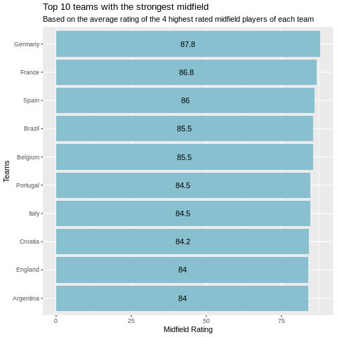

```python
%%R

mid_home <-
  df %>%
  select(date, home_team, home_team_mean_midfield_score) %>%
  rename(team = home_team, midfield_rating = home_team_mean_midfield_score)

mid_away <-
  df %>%
  select(date, away_team, away_team_mean_midfield_score) %>%
  rename(team = away_team, midfield_rating = away_team_mean_midfield_score)

mid_rating <- drop_na(rbind(mid_home, mid_away))

latest_mid_rating <-
  mid_rating %>%
  arrange(team, desc(date)) %>%
  group_by(team) %>%
  mutate(row_number = row_number(team)) %>%
  filter(row_number == 1) %>%
  arrange(-midfield_rating) %>%
  select(-date, -row_number)

ggplot(data = head(latest_mid_rating, 10), mapping=aes(x=midfield_rating, y=reorder(team, midfield_rating), label=midfield_rating)) +
  geom_col(fill= "#88C0D0") +
  geom_text(position = position_stack(vjust = 0.5)) +
  labs(title = "Top 10 teams with the strongest midfield",
       subtitle = "Based on the average rating of the 4 highest rated midfield players of each team",
       x = "Midfield Rating",
       y = "Teams")
```

### Top 10 offenses in 2022

These are the 10 countries with the best strikers using the fifa score metric.

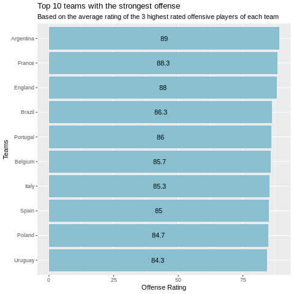

```python
%%R

off_home <-
  df %>%
  select(date, home_team, home_team_mean_offense_score) %>%
  rename(team = home_team, offense_rating = home_team_mean_offense_score)

off_away <-
  df %>%
  select(date, away_team, away_team_mean_offense_score) %>%
  rename(team = away_team, offense_rating = away_team_mean_offense_score)

off_rating <- drop_na(rbind(off_home, off_away))

latest_off_rating <-
  off_rating %>%
  arrange(team, desc(date)) %>%
  group_by(team) %>%
  mutate(row_number = row_number(team)) %>%
  filter(row_number == 1) %>%
  arrange(-offense_rating) %>%
  select(-date, -row_number)

ggplot(data = head(latest_off_rating, 10), mapping=aes(x=offense_rating, y=reorder(team, offense_rating), label=offense_rating)) +
  geom_col(fill="#88C0D0") +
  geom_text(position = position_stack(vjust = 0.5)) +
  labs(title="Top 10 teams with the strongest offense",
      subtitle="Based on the average rating of the 3 highest rated offensive players of each team",
      x="Offense Rating",
      y="Teams")
```

### Is there a home advantage?

From the data that has been gathered, there could be a correlation between playing at home and winning

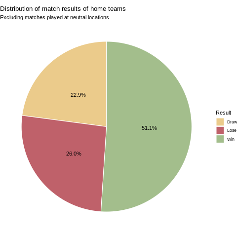

```python
%%R

home_team_advantage <-
  df %>%
  filter(neutral_location == FALSE) %>%
  count(home_team_result) %>%
  mutate(percentage = label_percent()(n/sum(n)))

ggplot(data = home_team_advantage, mapping=aes(x="", y=n, fill=home_team_result)) +
  geom_bar(width = 1, stat = "identity", color="white") +
  geom_text(aes(label=paste0(percentage)), position= position_stack(vjust=0.5)) +
  coord_polar("y") +
  scale_fill_manual(values = c("#EBCB8B", "#BF616A",
                               "#A3BE8C")) +
  theme_void() +
  labs(title = "Distribution of match results of home teams",
       subtitle = "Excluding matches played at neutral locations",
       fill="Result")
```

### Correlation Plot

- There is a high correlation between the fifa points of the home and away team : this means that good teams play against each other a lot.
- The rank is negatively correlated with the fifa scores. This is probably due to the fact that before 2013 we have a lot of missing data for these scores.
- Having a good goalkeeper is highly correlated with having a good midfield and offense.

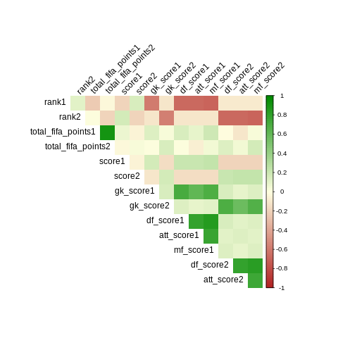

```python
%%R

# select numeric columns only
input_numeric_data <- input_data %>%
  select_if(is.numeric) %>%
  drop_na()

# rename variables for easier correlation plot visualization
input_numeric_data <- input_numeric_data %>% rename(
  rank1 = home_team_fifa_rank,
  rank2 = away_team_fifa_rank,
  total_fifa_points1 = home_team_total_fifa_points,
  total_fifa_points2 = away_team_total_fifa_points,
  score1 = home_team_score,
  score2 = away_team_score,
  gk_score1 = home_team_goalkeeper_score,
  gk_score2 = away_team_goalkeeper_score,
  df_score1 = home_team_mean_defense_score,
  df_score2 = away_team_mean_defense_score,
  att_score1 = home_team_mean_offense_score,
  att_score2 = away_team_mean_offense_score,
  mf_score1 = home_team_mean_midfield_score,
  mf_score2 = away_team_mean_midfield_score
)

# create correlation plot
input_numeric_data %>%
  cor() %>%
  corrplot(
    type = "upper",
    diag = FALSE,
    col=colorRampPalette(c("firebrick","lightyellow","green4"))(100),
    method = "shade",
    shade.col = NA,
    tl.col = "black",
    tl.srt = 45
  )
```

## Data Processing / Feature Engineering

We create new variables that we will use in out logistic regression.

```python
df['date'] = pd.to_datetime(df['date'])

df['rank_difference'] = df['home_team_fifa_rank'] - df['away_team_fifa_rank']

df['average_rank'] = (df['home_team_fifa_rank'] + df['away_team_fifa_rank'])/2

df['point_difference'] = df['home_team_total_fifa_points'] - df['away_team_total_fifa_points']

df['score_difference'] = df['home_team_score'] - df['away_team_score']

df['is_won'] = df['score_difference'] > 0 # take draw as a loss

df['is_stake'] = df['tournament'] != 'Friendly'
```

## Logistic Regression Model

win = average_rank + rank_difference + point_difference

```python
X, y = df.loc[:,['average_rank', 'rank_difference', 'point_difference']], df['is_won']
X_train, X_test, y_train, y_test = train_test_split(
    X, y, test_size=0.2) # the test set is 20% of the size of the whole df

logreg = linear_model.LogisticRegression(C=1e-5) # high C means overfitting the training data
features = PolynomialFeatures(degree=2) # deals with complex classification
model = Pipeline([
    ('polynomial_features', features),
    ('logistic_regression', logreg)
])
model = model.fit(X_train, y_train)
```

### Figures (AUC Score / Confusion Matrix)

- **AUC Score** : In this case, the model is likely to assign larger probabilities to random positive examples than random negatives. The model is better than guessing the outcome of a football match. The more the ROC curve is in the top left, the better is the classifier.
- **Confusion Matrix** : We can see that both for the test set and the training set, the model assigns a lot more True Positives and Negatives than False Positives and Negatives.

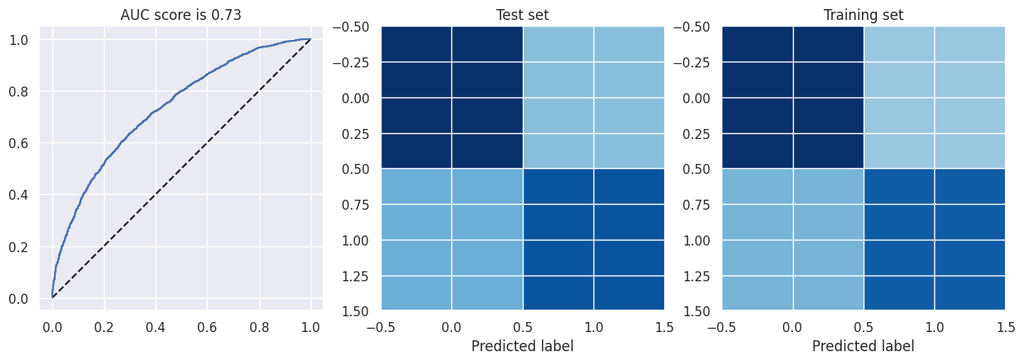

```python
# AUC Score / ROC Curve
fpr, tpr, _ = roc_curve(y_test, model.predict_proba(X_test)[:,1])
plt.figure(figsize=(15,5))
ax = plt.subplot(1,3,1)
ax.plot([0, 1], [0, 1], 'k--')
ax.plot(fpr, tpr)
ax.set_title('AUC score is {0:0.2}'.format(roc_auc_score(y_test, model.predict_proba(X_test)[:,1])))
ax.set_aspect(1)

# CM Test Set
ax = plt.subplot(1,3,2)
cm = confusion_matrix(y_test, model.predict(X_test))
ax.imshow(cm, cmap='Blues', clim = (0, cm.max()))
ax.set_xlabel('Predicted label')
ax.set_title('Test set')

# CM Training Set
ax = plt.subplot(1,3,3)
cm = confusion_matrix(y_train, model.predict(X_train))
ax.imshow(cm, cmap='Blues', clim = (0, cm.max()))
ax.set_xlabel('Predicted label')
ax.set_title('Training set')
```

```python
# List of all Teams in 2022 World Cup
teams_worldcup = ['Qatar', 'Ecuador', 'Senegal', 'Netherlands', 'England', 'Iran', 'USA',
                  'Wales', 'Argentina', 'Saudi Arabia', 'Mexico', 'Poland', 'France',
                  'Australia', 'Denmark', 'Tunisia', 'Spain', 'Costa Rica', 'Germany',
                  'Japan', 'Belgium', 'Canada', 'Morocco', 'Croatia', 'Brazil', 'Serbia',
                  'Switzerland', 'Cameroon', 'Portugal', 'Ghana', 'Uruguay', 'South Korea']
```

```python
# Gets the most recent stats
world_cup_rankings_home = df[['home_team', 'home_team_fifa_rank', 'home_team_total_fifa_points']].loc[df['home_team'].isin(
    teams_worldcup) & (df['date'] > '2021-01-01')]
world_cup_rankings_away = df[['away_team', 'away_team_fifa_rank', 'away_team_total_fifa_points']
                             ].loc[df['away_team'].isin(teams_worldcup) & (df['date'] > '2021-01-01')]
world_cup_rankings_home = world_cup_rankings_home.set_index(['home_team'])
```

```python
# Divide the performance into Home/Away and get the means of the recent stats
world_cup_rankings_home = world_cup_rankings_home.groupby('home_team').mean()
world_cup_rankings_away = world_cup_rankings_away.groupby('away_team').mean()
```

```python
from tqdm import tqdm

simulation_winners = list()
simulation_results_winners = list()
simulation_results_round16 = list()
simulation_df_round16 = list()
simulation_results_quarterfinal = list()
simulation_df_quarterfinal = list()
simulation_results_semifinal = list()
simulation_df_semifinal = list()

n_simulations = 1000  # Number of Simulations

for j in tqdm(range(n_simulations)):
    # the teams that we think will get out of the group stages
    candidates = ['Senegal', 'Netherlands', 'England', 'USA', 'Argentina', 'Poland', 'France',
                  'Denmark', 'Spain', 'Germany', 'Belgium', 'Croatia', 'Brazil', 'Serbia', 'Portugal', 'Uruguay']
    finals = ['round_of_16', 'quarterfinal', 'semifinal', 'final']

    for f in finals:
        iterations = int(len(candidates) / 2)
        winners = []
        prob = []

        for i in range(iterations):
            home = candidates[i*2]
            away = candidates[i*2+1]

            row = pd.DataFrame(
                np.array([[np.nan, np.nan, True]]), columns=X_test.columns)
            home_rank = world_cup_rankings_home.loc[home,
                                                    'home_team_fifa_rank']
            home_points = world_cup_rankings_home.loc[home,
                                                      'home_team_total_fifa_points']
            opp_rank = world_cup_rankings_away.loc[away, 'away_team_fifa_rank']
            opp_points = world_cup_rankings_away.loc[away,
                                                     'away_team_total_fifa_points']
            row['average_rank'] = (home_rank + opp_rank) / 2
            row['rank_difference'] = home_rank - opp_rank
            row['point_difference'] = home_points - opp_points
            home_win_prob = model.predict_proba(row)[:, 1][0]

            # we add some uncertainty by plugging the probabilities into a binomial distribution
            simulated_outcome = np.random.binomial(1, home_win_prob)
            winners.append(
                away) if simulated_outcome <= 0.5 else winners.append(home)
            prob.append(
                1 - simulated_outcome) if simulated_outcome <= 0.5 else prob.append(simulated_outcome)

        if f == 'round_of_16':
            step_16 = ['round_16'] * 8
            candidates_round_16 = zip(step_16, winners, prob)
            df_candidates_round_16 = pd.DataFrame(
                candidates_round_16, columns=['Step', 'Team', 'Prob'])
            simulation_df_round16.append(df_candidates_round_16)
            simulation_results_round16.append(winners)

        if f == 'quarterfinal':
            step_quarterfinal = ['quarterfinal'] * 4
            candidates_quarterfinal = zip(step_quarterfinal, winners, prob)
            df_candidates_quarterfinal = pd.DataFrame(
                candidates_quarterfinal, columns=['Step', 'Team', 'Prob'])
            simulation_df_quarterfinal.append(df_candidates_quarterfinal)
            simulation_results_quarterfinal.append(winners)

        if f == 'semifinal':
            step_semifinal = ['semifinal'] * 2
            candidates_semifinal = zip(step_semifinal, winners, prob)
            df_candidates_semifinal = pd.DataFrame(
                candidates_semifinal, columns=['Step', 'Team', 'Prob'])
            simulation_df_semifinal.append(df_candidates_semifinal)
            simulation_results_semifinal.append(winners)

        if f == 'final':
            step_final = ['final'] * 1
            candidates_final = zip(step_final, winners, prob)
            df_candidates_final = pd.DataFrame(
                candidates_final, columns=['Step', 'Team', 'Prob'])
            simulation_winners.append(df_candidates_final)
            simulation_results_winners.append(winners)

        candidates = winners

df_candidates_round_16 = pd.concat(simulation_df_round16)
df_candidates_quarterfinal = pd.concat(simulation_df_quarterfinal)
df_candidates_semifinal = pd.concat(simulation_df_semifinal)
df_candidates_final = pd.concat(simulation_winners)

df_results = pd.concat([df_candidates_round_16, df_candidates_quarterfinal,
                       df_candidates_semifinal, df_candidates_final])  # final DataFrame

simulation_results_round16 = sum(simulation_results_round16, [])
simulation_results_quarterfinal = sum(simulation_results_quarterfinal, [])
simulation_results_semifinal = sum(simulation_results_semifinal, [])
simulations_winners = sum(simulation_results_winners, [])
```

### Barplot of steps by teams

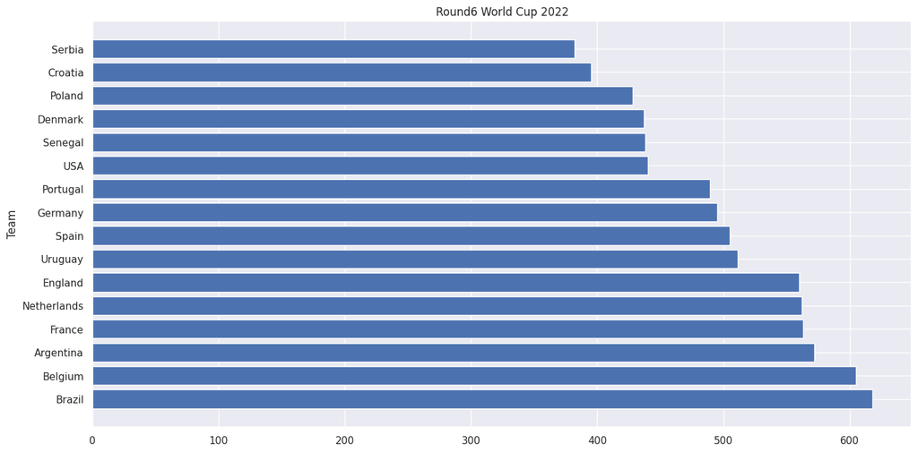

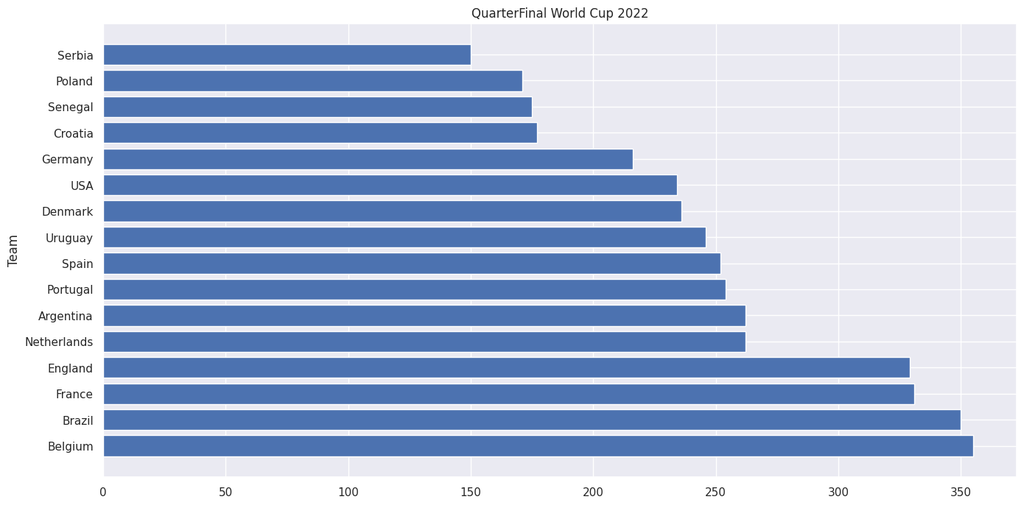

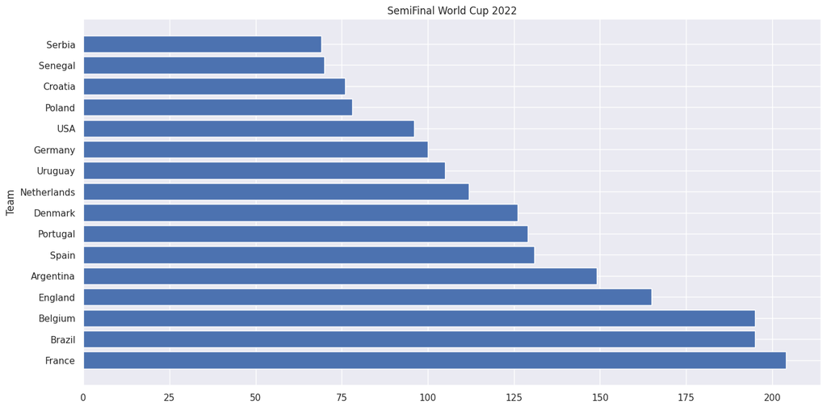

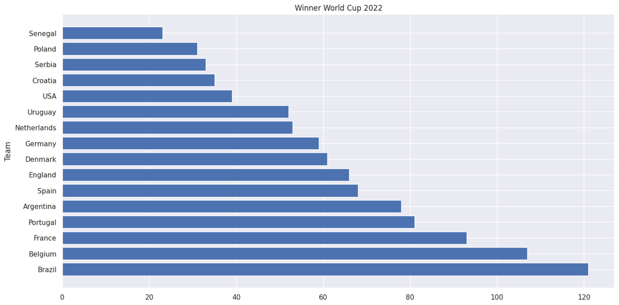

```python
from collections import Counter
from matplotlib import figure

lst_results = [simulation_results_round16,simulation_results_quarterfinal,simulation_results_semifinal,simulations_winners]
for i in lst_results:
    results = Counter(i).most_common()
    x,y = zip(*results)

    fig,ax = plt.subplots(figsize=(16,8))

    ax.barh(x, y)

    ax.set_ylabel('Team')

    if i == simulation_results_round16:
        ax.set_title('Round6 World Cup 2022')
    if i == simulation_results_quarterfinal:
        ax.set_title('QuarterFinal World Cup 2022')
    if i == simulation_results_semifinal:
        ax.set_title('SemiFinal World Cup 2022')
    if i == simulations_winners:
        ax.set_title('Winner World Cup 2022')


    plt.show()
```

### Barplot by team and step

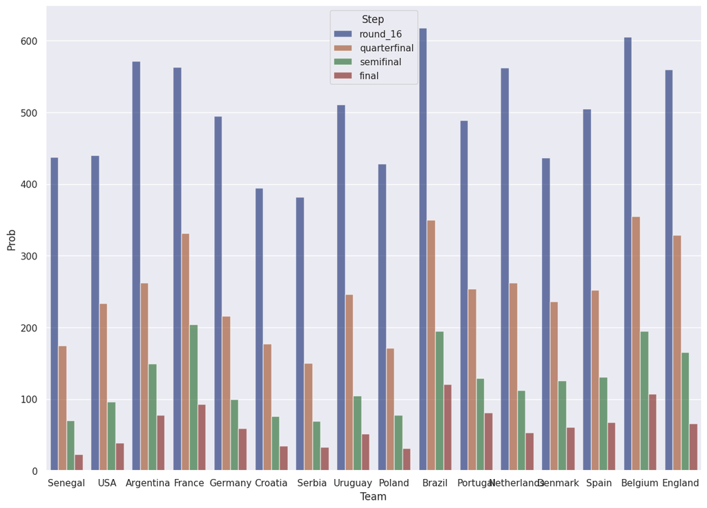

```python
sns.set_theme(style="whitegrid")
sns.set(rc={'figure.figsize':(14,10)})

g = sns.barplot(data=df_results, x="Team",y='Prob', hue="Step", estimator=sum, palette="dark", alpha=.6)
```